# R Notebook

## Setup

```r
setwd("/Users/anjali/Documents/university/Econ_5305/code_directory/ch4_summary_submission/")
rm(list = ls())
```

```r
library(openxlsx)
library(readxl)
library(ggplot2)
library(dynlm)
library(forecast)
library(urca)
library(lubridate)
library(TSstudio)
```

```r
excel_sheets("ch4_data.xlsx")
```

```
[1] "monthly"       "quarterly"     "raw_quarterly" "raw_monthly"
```

```r
data_monthly <- read_excel("ch4_data.xlsx", sheet ="monthly")
data_quarterly <- read_excel("ch4_data.xlsx", sheet ="quarterly")
```

# QUESTION 1

### 1.1 Read Time Series for Montly Data

```r
View(data_monthly)
PRICE <- ts(data_monthly$HOUSE_INDEX, frequency = 12, start = c(1987,1,1))
INTEREST <- ts(data_monthly$INTEREST_RATE, frequency = 12, start = c(1987,1,1))
```

### 1.2 Basic EDA

```r
cat("House Price - Montly")
```

```
House Price - Montly
```

```r
summary(PRICE)
```

```
   Min. 1st Qu.  Median    Mean 3rd Qu.    Max.
  63.73   81.68  140.66  139.27  177.30  308.34
```

```r
cat("Standard deviation: ", sd(PRICE))
```

```
Standard deviation:  58.02002
```

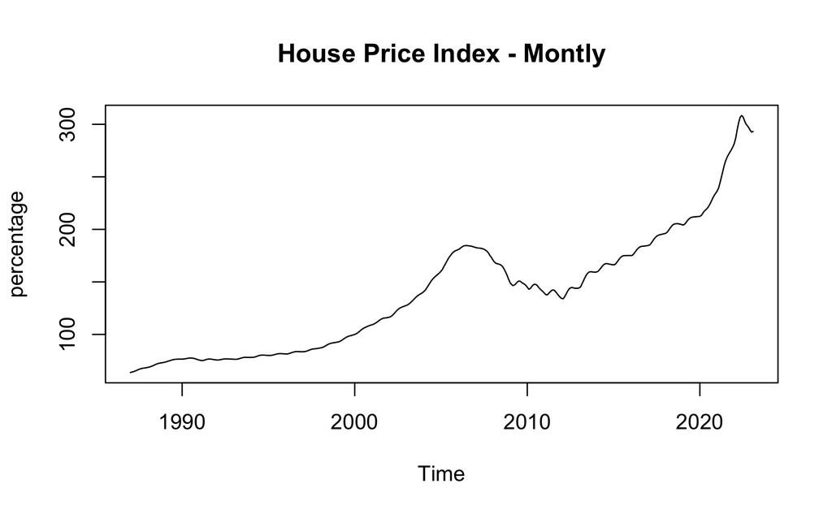

```r
ts.plot(PRICE, main = "House Price Index - Montly", ylab="percentage")
```

```r
ur.df(PRICE,type="drift",lags=0)
```

```
###############################################################
# Augmented Dickey-Fuller Test Unit Root / Cointegration Test #
###############################################################

The value of the test statistic is: 5.7206 54.5556
```

```r
cat("Interest Rate - Montly")
```

```
Interest Rate - Montly
```

```r
summary(INTEREST)
```

```
   Min. 1st Qu.  Median    Mean 3rd Qu.    Max.
  2.684   4.301   6.246   6.313   7.858  11.260
```

```r
cat("Standard deviation: ", sd(INTEREST))
```

```
Standard deviation:  2.184364
```

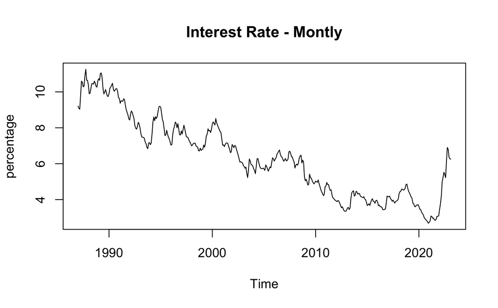

```r
ts.plot(INTEREST, main = "Interest Rate - Montly", ylab="percentage")
```

```r
ur.df(INTEREST,type="drift",lags=0)
```

```
###############################################################
# Augmented Dickey-Fuller Test Unit Root / Cointegration Test #
###############################################################

The value of the test statistic is: -1.4369 1.2614
```

** Both time series have a unit.** We will transform the timeseries and use the Growth series for house price index and use the first difference for interest rate.

```r
dlogPRICE <- diff(log(PRICE))
dINTEREST <- diff(INTEREST)
cat("House Price - Annual")
```

```
House Price - Annual
```

```r
summary(dlogPRICE)
```

```
      Min.    1st Qu.     Median       Mean    3rd Qu.       Max.
-0.0228514 -0.0003137  0.0036795  0.0035243  0.0079748  0.0269309
```

```r
cat("Standard deviation: ", sd(dlogPRICE))
```

```
Standard deviation:  0.006951601
```

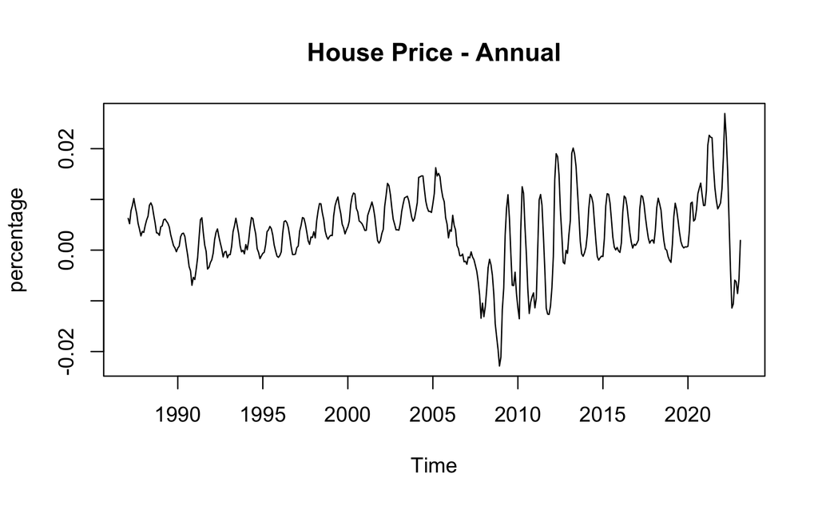

```r
ts.plot(dlogPRICE, main = "House Price - Annual", ylab="percentage")
```

```r
ur.df(dlogPRICE,type="drift",lags=1)
```

```
###############################################################
# Augmented Dickey-Fuller Test Unit Root / Cointegration Test #
###############################################################

The value of the test statistic is: -9.524 45.3554
```

```r
cat("Interest Rate - Annual")
```

```
Interest Rate - Annual
```

```r
summary(dINTEREST)
```

```
     Min.   1st Qu.    Median      Mean   3rd Qu.      Max.
-0.801500 -0.127500 -0.032500 -0.006805  0.082000  0.889500
```

```r
cat("Standard deviation: ", sd(dINTEREST))
```

```
Standard deviation:  0.209434
```

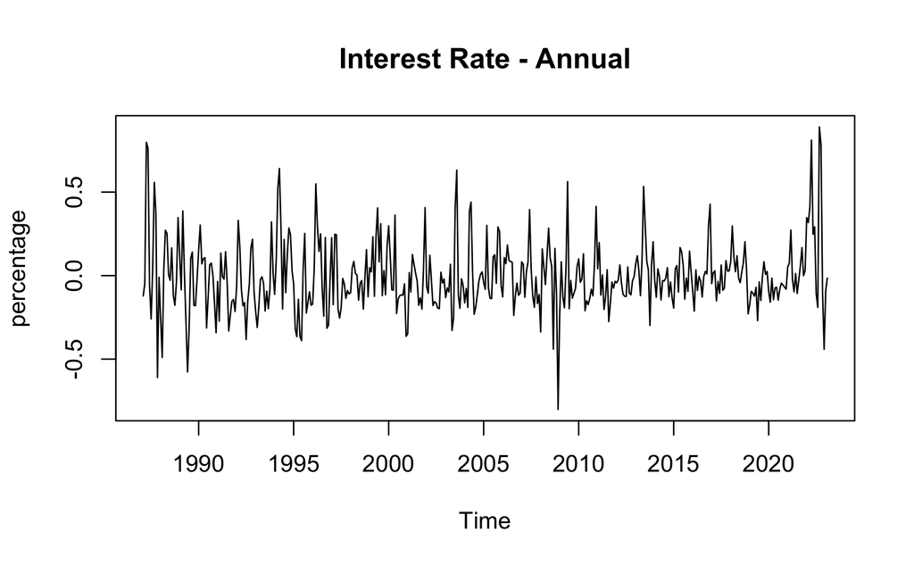

```r
ts.plot(dINTEREST, main = "Interest Rate - Annual", ylab="percentage")
```

```r
ur.df(dINTEREST,type="drift",lags=0)
```

```
###############################################################
# Augmented Dickey-Fuller Test Unit Root / Cointegration Test #
###############################################################

The value of the test statistic is: -14.6709 107.6185
```

### 2.3 ACF and PACF analysis

```r
par(mfrow=c(2,2) , mar = c(3, 2, 3, 2))
acf(PRICE, main = "ACF: House Index - Time Series")
pacf(PRICE, main = "PACF: House Index - Time Series")
```

```r
acf(INTEREST, main = "ACF: Interest Rate - Time Series")
pacf(INTEREST, main = "PACF: Interest Rate - Time Series")
```

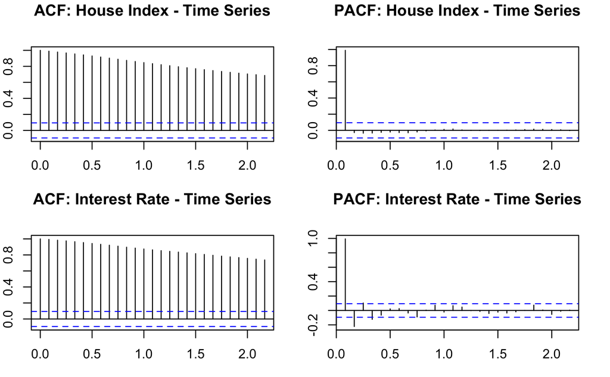

```r
par(mfrow=c(2,2) , mar = c(3, 2, 3, 2))
```

```r
acf(dlogPRICE, main = "ACF: House Index - Growth Series")
pacf(dlogPRICE, main = "PACF: House Index - Growth Series")
```

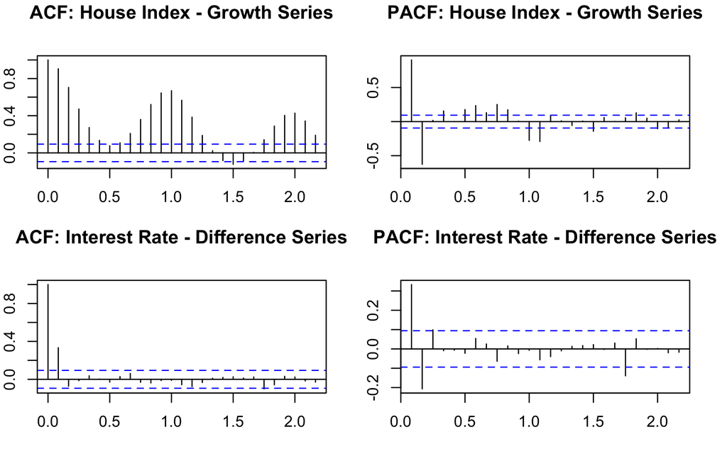

```r
acf(dINTEREST, main = "ACF: Interest Rate - Difference Series")
pacf(dINTEREST, main = "PACF: Interest Rate - Difference Series")
```

#### Interpretations

The ACF and PACF for House Price Index and Interest Rate look very similar. They both show very strong autocorrelation since in the ACF the spikes fall very gradually. In the PACF we see one spike for for House Price Index Time Series but 2 spikes in the interest rate. Althpugh this would indicate AR(1) and AR(2) model we should not be using analysis from the time series for out model since both series are non-stationary,making their ACF and PACF less credible.

It is better to use the transformed series for ACF and PACF analysis. Looking at the ACF and PACF of the transformed series we see that they are very different now. The House Price Index Growth series shows a much faster fall in autocorrelation than previously. We also see some spike patterns that alternate that are indicative of ARMA model and more specifically a seasonal pattern. The ACF for the interest rates difference series has only one spike we cannot find any gradual reduction in autocorrelation. This looks more like a MA model possibly MA(1).

Both non-stationary time series prior to transformations show higher autocorrelation. This high autocorrelation is a result of the underlying trends in the original time series.

# QUESTION 2

```r
model1<-dynlm(dlogPRICE ~ lag(dlogPRICE,-1)+ lag(dlogPRICE,-2))
summary(model1)
```

```
Time series regression with "ts" data:
Start = 1987(4), End = 2023(2)

Call:
dynlm(formula = dlogPRICE ~ lag(dlogPRICE, -1) + lag(dlogPRICE,
    -2))

Residuals:
       Min         1Q     Median         3Q        Max
-0.0072031 -0.0010166 -0.0001534  0.0009809  0.0160116

Coefficients:
                     Estimate Std. Error t value Pr(>|t|)
(Intercept)         0.0005594  0.0001254   4.463 1.04e-05 ***
lag(dlogPRICE, -1)  1.4794493  0.0377444  39.196  < 2e-16 ***
lag(dlogPRICE, -2) -0.6354657  0.0378150 -16.805  < 2e-16 ***
---
Signif. codes:  0 ‘***’ 0.001 ‘**’ 0.01 ‘*’ 0.05 ‘.’ 0.1 ‘ ’ 1

Residual standard error: 0.002308 on 428 degrees of freedom
Multiple R-squared:  0.8907,    Adjusted R-squared:  0.8902
F-statistic:  1745 on 2 and 428 DF,  p-value: < 2.2e-16
```

```r
model2<-dynlm(dlogPRICE ~ lag(dlogPRICE,-1)+ lag(dlogPRICE,-2) + lag(dINTEREST,-1) + lag(dINTEREST,-2))
summary(model2)
```

```
Time series regression with "ts" data:
Start = 1987(4), End = 2023(2)

Call:
dynlm(formula = dlogPRICE ~ lag(dlogPRICE, -1) + lag(dlogPRICE,
    -2) + lag(dINTEREST, -1) + lag(dINTEREST, -2))

Residuals:
       Min         1Q     Median         3Q        Max
-0.0072559 -0.0010660 -0.0001654  0.0009659  0.0161932

Coefficients:
                     Estimate Std. Error t value Pr(>|t|)
(Intercept)         0.0005330  0.0001262   4.222 2.96e-05 ***
lag(dlogPRICE, -1)  1.4844032  0.0383368  38.720  < 2e-16 ***
lag(dlogPRICE, -2) -0.6348576  0.0381448 -16.643  < 2e-16 ***
lag(dINTEREST, -1) -0.0001638  0.0005716  -0.286    0.775
lag(dINTEREST, -2) -0.0008772  0.0005679  -1.545    0.123
---
Signif. codes:  0 ‘***’ 0.001 ‘**’ 0.01 ‘*’ 0.05 ‘.’ 0.1 ‘ ’ 1

Residual standard error: 0.002305 on 426 degrees of freedom
Multiple R-squared:  0.8915,    Adjusted R-squared:  0.8905
F-statistic: 875.3 on 4 and 426 DF,  p-value: < 2.2e-16
```

```r
model3<-dynlm(dlogPRICE ~ lag(dlogPRICE,-1)+ lag(dlogPRICE,-2) + lag(dlogPRICE,-3)+ lag(dlogPRICE,-4))
summary(model3)
```

```
Time series regression with "ts" data:
Start = 1987(6), End = 2023(2)

Call:
dynlm(formula = dlogPRICE ~ lag(dlogPRICE, -1) + lag(dlogPRICE,
    -2) + lag(dlogPRICE, -3) + lag(dlogPRICE, -4))

Residuals:
       Min         1Q     Median         3Q        Max
-0.0079649 -0.0010601 -0.0001402  0.0008628  0.0159186

Coefficients:
                     Estimate Std. Error t value Pr(>|t|)
(Intercept)         0.0004513  0.0001298   3.478 0.000558 ***
lag(dlogPRICE, -1)  1.4913857  0.0481339  30.984  < 2e-16 ***
lag(dlogPRICE, -2) -0.5641522  0.0863145  -6.536 1.82e-10 ***
lag(dlogPRICE, -3) -0.2171662  0.0863704  -2.514 0.012294 *
lag(dlogPRICE, -4)  0.1614241  0.0482348   3.347 0.000891 ***
---
Signif. codes:  0 ‘***’ 0.001 ‘**’ 0.01 ‘*’ 0.05 ‘.’ 0.1 ‘ ’ 1

Residual standard error: 0.002282 on 424 degrees of freedom
Multiple R-squared:  0.894, Adjusted R-squared:  0.8929
F-statistic: 893.5 on 4 and 424 DF,  p-value: < 2.2e-16
```

```r
model4<-dynlm(dlogPRICE ~ lag(dlogPRICE,-1)+ lag(dlogPRICE,-2) + lag(dlogPRICE,-3)+ lag(dlogPRICE,-4) + lag(dINTEREST,-1) + lag(dINTEREST,-2) )
summary(model4)
```

```
Time series regression with "ts" data:
Start = 1987(6), End = 2023(2)

Call:
dynlm(formula = dlogPRICE ~ lag(dlogPRICE, -1) + lag(dlogPRICE,
    -2) + lag(dlogPRICE, -3) + lag(dlogPRICE, -4) + lag(dINTEREST,
    -1) + lag(dINTEREST, -2))

Residuals:
       Min         1Q     Median         3Q        Max
-0.0080616 -0.0010728 -0.0001526  0.0008303  0.0161008

Coefficients:
                     Estimate Std. Error t value Pr(>|t|)
(Intercept)         0.0004213  0.0001307   3.224  0.00136 **
lag(dlogPRICE, -1)  1.4929355  0.0489663  30.489  < 2e-16 ***
lag(dlogPRICE, -2) -0.5478025  0.0874582  -6.264 9.28e-10 ***
lag(dlogPRICE, -3) -0.2361959  0.0867866  -2.722  0.00677 **
lag(dlogPRICE, -4)  0.1687539  0.0483250   3.492  0.00053 ***
lag(dINTEREST, -1) -0.0003140  0.0005794  -0.542  0.58819
lag(dINTEREST, -2) -0.0009031  0.0005690  -1.587  0.11320
---
Signif. codes:  0 ‘***’ 0.001 ‘**’ 0.01 ‘*’ 0.05 ‘.’ 0.1 ‘ ’ 1

Residual standard error: 0.002277 on 422 degrees of freedom
Multiple R-squared:  0.8949,    Adjusted R-squared:  0.8934
F-statistic: 598.9 on 6 and 422 DF,  p-value: < 2.2e-16
```

#### Conclusion

The Adjusted R-Squares are as follows Model 1 - 0.8902, Model 2 - 0.8905, Model 3, - 0.8929, Model 4, - 0.8934

# Question 3

### 3.1 Read Time Series for Quarterly Data

```r
#View(data_quarterly)
PRICE <- ts(data_quarterly$HOUSE_INDEX, frequency = 4, start = c(1987,1,1))
INTEREST <- ts(data_quarterly$INTEREST_RATE, frequency = 4, start = c(1987,1,1))
```

### 1.2 Basic EDA

```r
cat("House Price - quarterly")
```

```
House Price - quarterly
```

```r
summary(PRICE)
```

```
   Min. 1st Qu.  Median    Mean 3rd Qu.    Max.
  64.11   81.62  140.75  138.56  175.70  305.57
```

```r
cat("Standard deviation: ", sd(PRICE))
```

```
Standard deviation:  57.32253
```

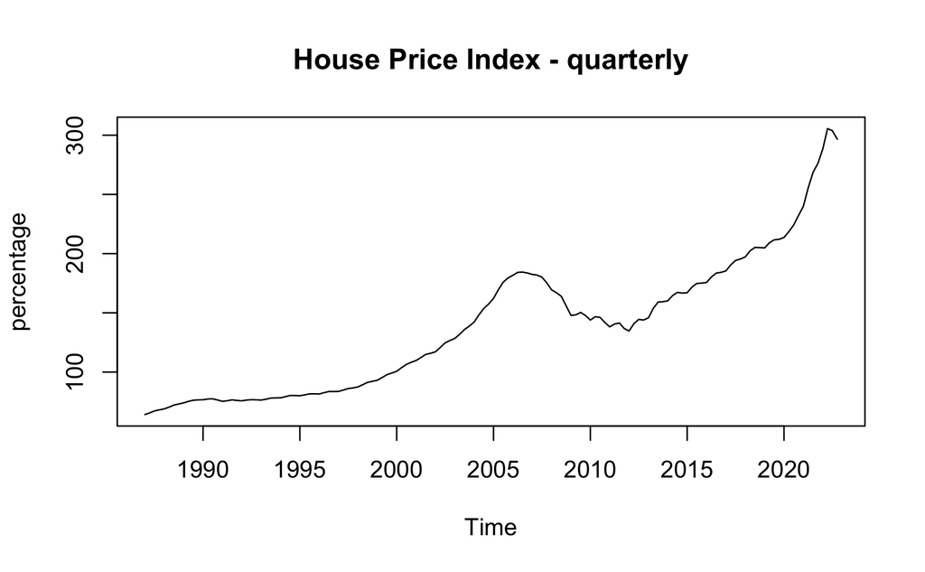

```r
ts.plot(PRICE, main = "House Price Index - quarterly", ylab="percentage")
```

```r
ur.df(PRICE,type="drift",lags=0)
```

```
###############################################################
# Augmented Dickey-Fuller Test Unit Root / Cointegration Test #
###############################################################

The value of the test statistic is: 3.885 23.6712
```

```r
cat("Interest Rate - quarterly")
```

```
Interest Rate - quarterly
```

```r
summary(INTEREST)
```

```
   Min. 1st Qu.  Median    Mean 3rd Qu.    Max.
  2.761   4.293   6.225   6.313   7.805  10.864
```

```r
cat("Standard deviation: ", sd(INTEREST))
```

```
Standard deviation:  2.187848
```

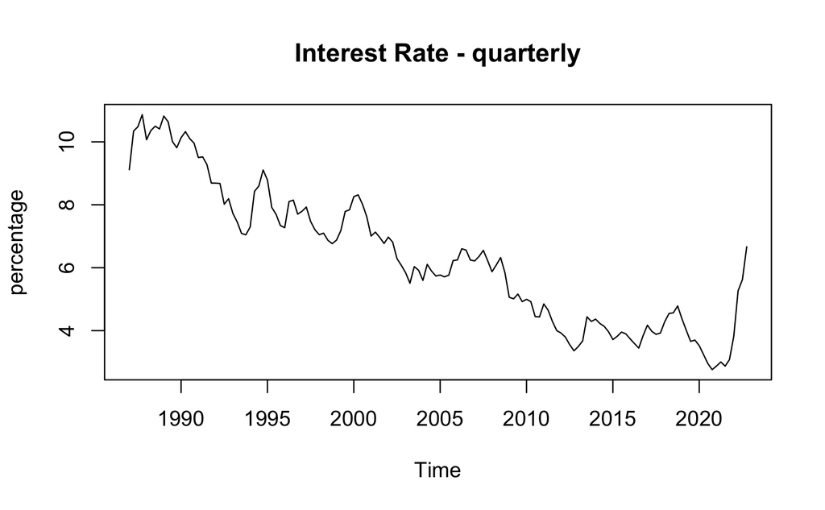

```r
ts.plot(INTEREST, main = "Interest Rate - quarterly", ylab="percentage")
```

```r
ur.df(INTEREST,type="drift",lags=0)
```

```
###############################################################
# Augmented Dickey-Fuller Test Unit Root / Cointegration Test #
###############################################################

The value of the test statistic is: -1.418 1.1563
```

**Both time series have a unit root.** We will transform the times eries and use the Growth series for house price index and use the first difference for interest rate.

```r
dlogPRICE <- diff(log(PRICE))
dINTEREST <- diff(INTEREST)
cat("House Price - Quarterly")
```

```
House Price - Quarterly
```

```r
summary(dlogPRICE)
```

```
     Min.   1st Qu.    Median      Mean   3rd Qu.      Max.
-0.053309  0.001204  0.012084  0.010711  0.022684  0.062633
```

```r
cat("Standard deviation: ", sd(dlogPRICE))
```

```
Standard deviation:  0.01896837
```

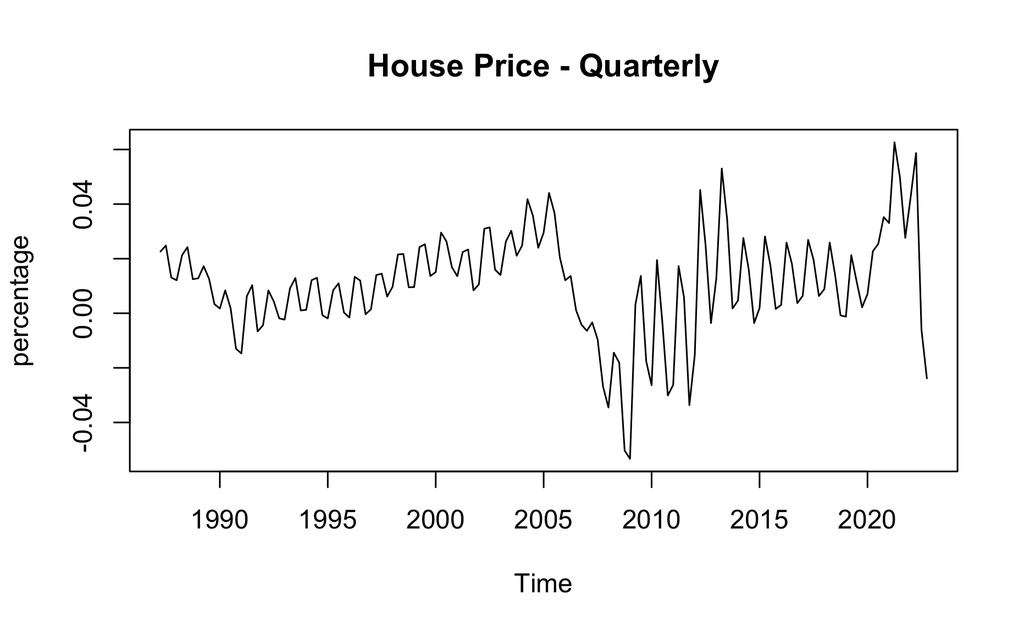

```r
ts.plot(dlogPRICE, main = "House Price - Quarterly", ylab="percentage")
```

```r
ur.df(dlogPRICE,type="drift",lags=1)
```

```
###############################################################
# Augmented Dickey-Fuller Test Unit Root / Cointegration Test #
###############################################################

The value of the test statistic is: -6.4686 20.9596
```

```r
cat("Interest Rate - Quarterly")
```

```
Interest Rate - Quarterly
```

```r
summary(dINTEREST)
```

```
    Min.  1st Qu.   Median     Mean  3rd Qu.     Max.
-0.86769 -0.24047 -0.06692 -0.01713  0.15830  1.44385
```

```r
cat("Standard deviation: ", sd(dINTEREST))
```

```
Standard deviation:  0.3742276
```

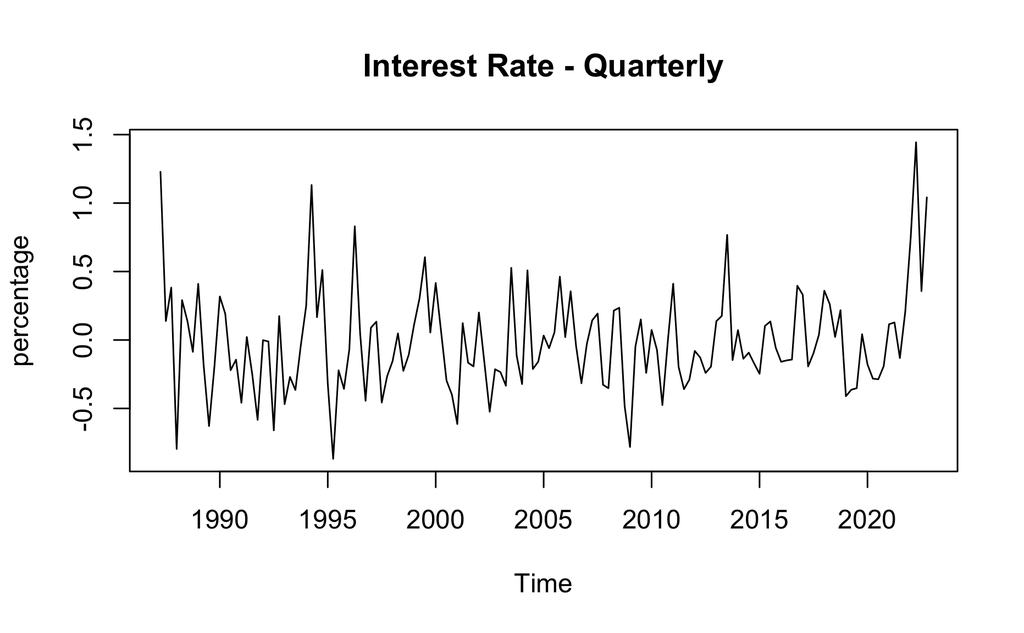

```r
ts.plot(dINTEREST, main = "Interest Rate - Quarterly", ylab="percentage")
```

```r
ur.df(dINTEREST,type="drift",lags=0)
```

```
###############################################################
# Augmented Dickey-Fuller Test Unit Root / Cointegration Test #
###############################################################

The value of the test statistic is: -9.3299 43.5247
```

### 2.3 ACF and PACF analysis

```r
par(mfrow=c(2,2) , mar = c(3, 2, 3, 2))
acf(PRICE, main = "ACF: House Index - Time Series")
pacf(PRICE, main = "PACF: House Index - Time Series")
```

```r
acf(INTEREST, main = "ACF: Interest Rate - Time Series")
pacf(INTEREST, main = "PACF: Interest Rate - Time Series")
```

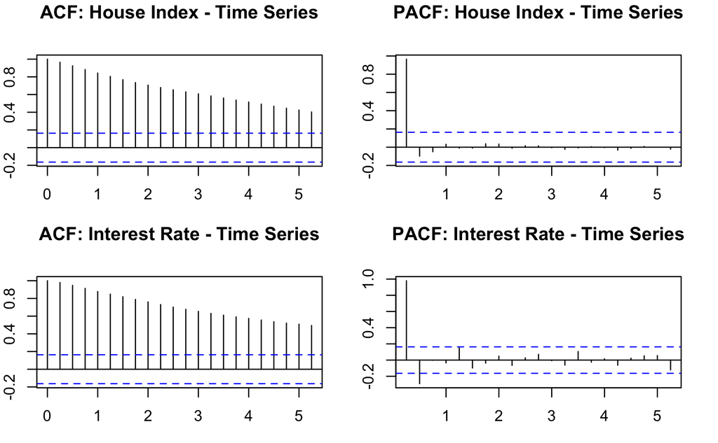

```r
par(mfrow=c(2,2) , mar = c(3, 2, 3, 2))
```

```r
acf(dlogPRICE, main = "ACF: House Index - Growth Series")
pacf(dlogPRICE, main = "PACF: House Index - Growth Series")
```

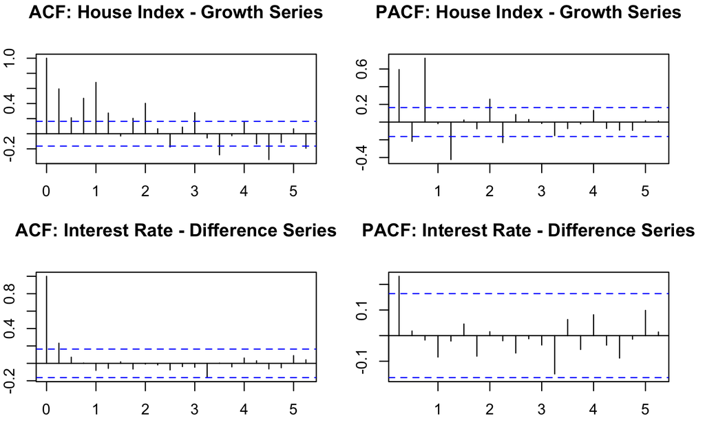

```r
acf(dINTEREST, main = "ACF: Interest Rate - Difference Series")
pacf(dINTEREST, main = "PACF: Interest Rate - Difference Series")
```

**Key Findings** Looking at the quarterly data time series the overall trend pattern is the same. Both time series have a unit root which we remove by transformations.

The ACFs for both time series show high autocorrelation values similar to the annual data. Looking at the PACF for time series for for House Price Index we see a single spike indicating AR(1) model. The PACF of Interest Rate Time Series has 2 spikes indicating AR(1) and AR(2).

However, as mentioned previously we will not be using the times series to create models as it is not stationary and has stochastic trend. The ACF for House Index - Growth Series has weaker auto correlations as compared to the time series. The number of spikes for each cycle is less about 4 as compared to the monthly data. The seasonality is there for for both the series but with different periodicity. Monthly = 12 and Quarterly = 4. The ACF interest Rate difference series has no reducing spikes and the PACf has only 1 spike. This looks almost like white noise or MA(1) process.

The ACF and PACF changes very similarly as seen in question 1. The overall patterns also seem quite similar suggesting similar models. A difference is in the frequency of the seasonality in the patterns.

# QUESTION 4

### 4.1 Models

```r
model5<-dynlm(dlogPRICE ~ lag(dlogPRICE,-1))
summary(model5)
```

```
Time series regression with "ts" data:
Start = 1987(3), End = 2022(4)

Call:
dynlm(formula = dlogPRICE ~ lag(dlogPRICE, -1))

Residuals:
      Min        1Q    Median        3Q       Max
-0.045620 -0.007819 -0.000279  0.007671  0.050466

Coefficients:
                   Estimate Std. Error t value Pr(>|t|)
(Intercept)        0.003970   0.001481   2.680  0.00825 **
lag(dlogPRICE, -1) 0.607720   0.068239   8.906  2.5e-15 ***
---
Signif. codes:  0 ‘***’ 0.001 ‘**’ 0.01 ‘*’ 0.05 ‘.’ 0.1 ‘ ’ 1

Residual standard error: 0.01524 on 140 degrees of freedom
Multiple R-squared:  0.3616,    Adjusted R-squared:  0.3571
F-statistic: 79.31 on 1 and 140 DF,  p-value: 2.501e-15
```

```r
model6<-dynlm(dlogPRICE ~ lag(dlogPRICE,-1)+ lag(dlogPRICE,-2))
summary(model6)
```

```
Time series regression with "ts" data:
Start = 1987(4), End = 2022(4)

Call:
dynlm(formula = dlogPRICE ~ lag(dlogPRICE, -1) + lag(dlogPRICE,
    -2))

Residuals:
      Min        1Q    Median        3Q       Max
-0.045121 -0.008139 -0.000353  0.006161  0.043865

Coefficients:
                    Estimate Std. Error t value Pr(>|t|)
(Intercept)         0.004977   0.001504   3.309  0.00120 **
lag(dlogPRICE, -1)  0.741630   0.083650   8.866 3.44e-15 ***
lag(dlogPRICE, -2) -0.226888   0.083778  -2.708  0.00762 **
---
Signif. codes:  0 ‘***’ 0.001 ‘**’ 0.01 ‘*’ 0.05 ‘.’ 0.1 ‘ ’ 1

Residual standard error: 0.01495 on 138 degrees of freedom
Multiple R-squared:  0.3924,    Adjusted R-squared:  0.3836
F-statistic: 44.56 on 2 and 138 DF,  p-value: 1.175e-15
```

```r
model7<-dynlm(dlogPRICE ~ lag(dlogPRICE,-1)+ lag(dlogPRICE,-2) + lag(dlogPRICE,-3))
summary(model7)
```

```
Time series regression with "ts" data:
Start = 1988(1), End = 2022(4)

Call:
dynlm(formula = dlogPRICE ~ lag(dlogPRICE, -1) + lag(dlogPRICE,
    -2) + lag(dlogPRICE, -3))

Residuals:
      Min        1Q    Median        3Q       Max
-0.047056 -0.004608  0.000289  0.004444  0.040148

Coefficients:
                    Estimate Std. Error t value Pr(>|t|)
(Intercept)         0.001275   0.001052   1.212    0.228
lag(dlogPRICE, -1)  0.886628   0.057368  15.455   <2e-16 ***
lag(dlogPRICE, -2) -0.799585   0.071548 -11.175   <2e-16 ***
lag(dlogPRICE, -3)  0.789205   0.060715  12.998   <2e-16 ***
---
Signif. codes:  0 ‘***’ 0.001 ‘**’ 0.01 ‘*’ 0.05 ‘.’ 0.1 ‘ ’ 1

Residual standard error: 0.01005 on 136 degrees of freedom
Multiple R-squared:  0.7292,    Adjusted R-squared:  0.7233
F-statistic: 122.1 on 3 and 136 DF,  p-value: < 2.2e-16
```

```r
model8<-dynlm(dlogPRICE ~ lag(dlogPRICE,-1)+ lag(dlogPRICE,-2) + lag(dlogPRICE,-3) + lag(dlogPRICE,-4))
summary(model8)
```

```
Time series regression with "ts" data:
Start = 1988(2), End = 2022(4)

Call:
dynlm(formula = dlogPRICE ~ lag(dlogPRICE, -1) + lag(dlogPRICE,
    -2) + lag(dlogPRICE, -3) + lag(dlogPRICE, -4))

Residuals:
      Min        1Q    Median        3Q       Max
-0.047017 -0.004674  0.000253  0.004499  0.040164

Coefficients:
                    Estimate Std. Error t value Pr(>|t|)
(Intercept)         0.001272   0.001066   1.193    0.235
lag(dlogPRICE, -1)  0.888271   0.086533  10.265  < 2e-16 ***
lag(dlogPRICE, -2) -0.801414   0.096602  -8.296 1.01e-13 ***
lag(dlogPRICE, -3)  0.790908   0.101296   7.808 1.49e-12 ***
lag(dlogPRICE, -4) -0.002045   0.091605  -0.022    0.982
---
Signif. codes:  0 ‘***’ 0.001 ‘**’ 0.01 ‘*’ 0.05 ‘.’ 0.1 ‘ ’ 1

Residual standard error: 0.01013 on 134 degrees of freedom
Multiple R-squared:  0.7292,    Adjusted R-squared:  0.7212
F-statistic: 90.23 on 4 and 134 DF,  p-value: < 2.2e-16
```

The Adjusted R-Squares for the Annual data - Model 1 - 0.8902, Model 2 - 0.8905, Model 3, - 0.8929, Model 4, - 0.8934 The Adjusted R-Squares for the Quarterly data - Model 5 - 0.3571 ,Model 6 - 0.38.36 ,Model 7 - 0.7233 ,Model 8 - 0.7212

Given all these models I would go for Model 1 or Model 4. Comparing quarterly data models to monthly data models clearly shows a drop in the explanatory power which is possibly due to there being less data points for creating a model.

### 4.2 Forecasting

```r
# Resetting out data since PRICE was used for both data
PRICE <- ts(data_monthly$HOUSE_INDEX, frequency = 12, start = c(1987,1,1))
dlogPRICE <- diff(log(PRICE))
g <- dlogPRICE

# we predict for 50 periods
n = 50
last = length(g) - n
```

```r
fcast1<-numeric(n)
coef1<-numeric(n)
model<-dynlm(g ~ lag(g,-1), start=c(1987,1), end=c(2018,12)) #fit AR(1)
for (i in 1:n){ #start a for loop
  fcast1[i]<-coef(model)[1]+coef(model)[2]*g[last+i]
  coef1[i]<-coef(model)[2]
} #end the loop
fcast1
```

```
 [1] -0.0019059159  0.0012830329  0.0062048301  0.0086255661  0.0074758758
 [6]  0.0055987047  0.0034980170  0.0018078519  0.0010300734  0.0006674819
[11]  0.0008588735  0.0008287203  0.0009644117  0.0037628160  0.0086122600
[16]  0.0088227827  0.0054512689  0.0057380717  0.0074549129  0.0103243907
[21]  0.0113090945  0.0122017596  0.0100821626  0.0082220661  0.0082405549
[26]  0.0108389946  0.0189527387  0.0207195938  0.0203764722  0.0202740472
[31]  0.0151403139  0.0113496634  0.0091558154  0.0076189768  0.0080831622
[36]  0.0086839477  0.0111806533  0.0169151562  0.0245911381  0.0204419914
[41]  0.0144639671  0.0054499372 -0.0032422769 -0.0100337809 -0.0092989904
[46] -0.0050804519 -0.0053587782 -0.0074505054 -0.0048689296  0.0019987661
```

```r
f1<-ts(fcast1, frequency = 12, start=c(2019,1))
c1<-ts(coef1, frequency = 12, start=c(2019,1))
```

```r
#Recursive Scheme
fcast2<-numeric(n)
coef2<-numeric(n)
for (i in 1:n){
  model<-dynlm(g ~ lag(g,-1), start=c(1987,1), end=c(2018,0+i))
  fcast2[i]<-coef(model)[1]+coef(model)[2]*g[last+i]
  coef2[i]<-coef(model)[2]
}
fcast2
```

```
 [1] -0.0019002661  0.0012955617  0.0062285673  0.0086601597  0.0075074840
 [6]  0.0056265961  0.0035171184  0.0018218721  0.0010399386  0.0006760348
[11]  0.0008625288  0.0008287203  0.0009614555  0.0037677542  0.0086230622
[16]  0.0088453556  0.0054740407  0.0057549712  0.0074620745  0.0103207358
[21]  0.0113016572  0.0121918643  0.0100761852  0.0082191186  0.0082374464
[26]  0.0108349897  0.0189490349  0.0207207471  0.0203470980  0.0202482370
[31]  0.0151398682  0.0113773064  0.0091968201  0.0076699718  0.0081265372
[36]  0.0087203389  0.0112184122  0.0169759918  0.0247984446  0.0206999534
[41]  0.0146816386  0.0055689866 -0.0032194879 -0.0100459941 -0.0092994857
[46] -0.0050566569 -0.0053364379 -0.0074404734 -0.0048457083  0.0020806963
```

```r
f2<-ts(fcast2, frequency = 12, start=c(2019,1))
c2<-ts(coef2, frequency = 12, start=c(2019,1))
```

```r
#Rolling Scheme
fcast3<-numeric(n)
coef3<-numeric(n)
for (i in 1:n){
  model<-dynlm(g ~ lag(g,-1), start=c(1987,0+i), end=c(2018,0+i)) #fit AR(1), note that both "start" and "end" depend on i
  fcast3[i]<-coef(model)[1]+coef(model)[2]*g[last+i]
  coef3[i]<-coef(model)[2]
}
fcast3
```

```
 [1] -0.0019002661  0.0012955617  0.0062285673  0.0086631007  0.0075009204
 [6]  0.0056153431  0.0035017041  0.0018108919  0.0010312593  0.0006707091
[11]  0.0008592483  0.0008283977  0.0009587049  0.0037651343  0.0086164392
[16]  0.0088349013  0.0054610011  0.0057329737  0.0074329837  0.0102866980
[21]  0.0112726821  0.0121679496  0.0100607380  0.0082047619  0.0082241330
[26]  0.0108161711  0.0189265891  0.0206912134  0.0203129135  0.0202152883
[31]  0.0151126726  0.0113566343  0.0091830308  0.0076606128  0.0081192060
[36]  0.0087134904  0.0112119358  0.0169680098  0.0247952985  0.0207014374
[41]  0.0146821518  0.0055681731 -0.0032215401 -0.0100424537 -0.0092866211
[46] -0.0050326236 -0.0053025831 -0.0073755355 -0.0047929944  0.0021196138
```

```r
f3<-ts(fcast3, frequency = 12, start=c(2019,1))
c3<-ts(coef3, frequency = 12, start=c(2019,1))
```

```r
g0<-window(g,start=c(2018,1))
plot(g0,col='black',main = "House Price Index, Monthly",ylab = "Growth rate",xlab = "Monthly")
lines(f1,col='blue')
```

```r
lines(f2,col='red')
lines(f3,col='green')
```

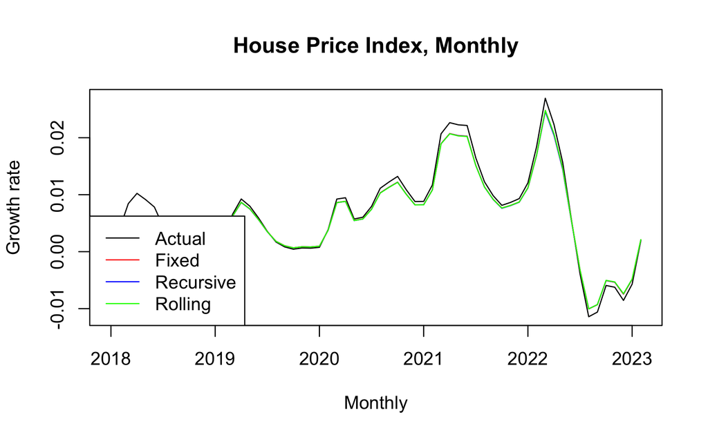

```r
legend("bottomleft", legend=c("Actual", "Fixed","Recursive","Rolling"), lty=c(1,1,1,1), col=c( "black","red", "blue","green"))
```

```r
c2
```

```
           Jan       Feb       Mar       Apr       May       Jun       Jul
2019 0.9027928 0.9025337 0.9028148 0.9035973 0.9034059 0.9031390 0.9022728
2020 0.9031648 0.9021468 0.9015240 0.9021836 0.9019268 0.9014439 0.9010889
2021 0.9012549 0.9008517 0.9011262 0.9014427 0.9002295 0.9003240 0.9007209
2022 0.9024660 0.9036076 0.9085200 0.9120859 0.9134977 0.9150653 0.9108286
2023 0.9090755 0.9123234
           Aug       Sep       Oct       Nov       Dec
2019 0.9020654 0.9021990 0.9022898 0.9025863 0.9028873
2020 0.9010337 0.9011169 0.9012002 0.9012055 0.9012435
2021 0.9018007 0.9027073 0.9037255 0.9028852 0.9022780
2022 0.9086677 0.9078886 0.9075036 0.9077383 0.9080521
2023
```

```r
plot(c1,col='blue',main = "Coefficients of Regression ",xlab = "Monthly",ylim = c(0.88,0.92))
lines(c2,col='red')
```

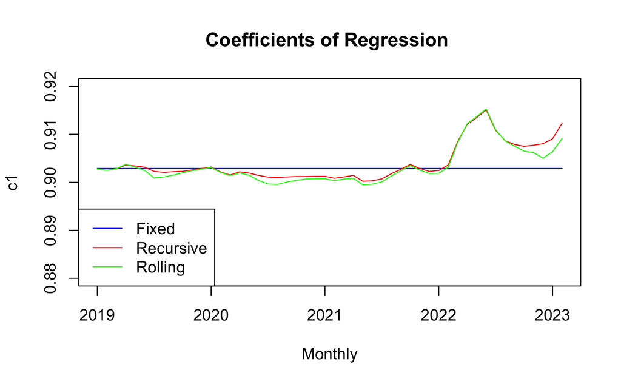

```r
lines(c3,col='green')

legend("bottomleft", legend=c("Fixed","Recursive","Rolling"), lty=c(1,1,1,1), col=c("blue", "red","green"))
```

**Conclusion:** We did the forecast using three schemes. 1. Fixed forecast 2. Recursive Forecast 3. Rolling Forecast. Although the forecast values are slightly different when plotting we see that the forecast of all three schemes are quite similar and all the lines overalap significantly.

Looking at the recursion coefficient plots we see that the recursive and rolling forecast coefficients increase around the time of the sudden rise in home prices that happened in 2021, 2022 . The scale is highly zoomed though.